# AI HACK 2018 GWAS (PCA on genome matrix)

```python
import numpy as np
import scipy as sp
import pandas as pd
```

## 1. Load de filez

Load the SNP files for chromosomes 15, 16, 17.

```python
SNP15 = pd.read_csv('D:/AI_Hack/GWAS_files/AIHack-SNP-Matrix-15.csv')
```

```python
SNP16 = pd.read_csv('D:/AI_Hack/GWAS_files/AIHack-SNP-Matrix-16.csv')
```

```python
SNP17 = pd.read_csv('D:/AI_Hack/GWAS_files/AIHack-SNP-Matrix-17.csv')
```

Load the patient data file and the computed SNP PCs.

```python
SNP_patients = pd.read_csv('D:/AI_Hack/GWAS_files/AIHack-Clinical.csv')
SNP_PCs = pd.read_csv('D:/AI_Hack/GWAS_files/AIHack-PCs.csv')
```

```python
SNP_patients.head()
```

|  | Unnamed: 0 | FamID | CAD | sex | age | tg | hdl | ldl |
| --- | --- | --- | --- | --- | --- | --- | --- | --- |
| 0 | 10002 | 10002 | 1 | 1 | 60 | NaN | NaN | NaN |
| 1 | 10004 | 10004 | 1 | 2 | 50 | 55.0 | 23.0 | 75.0 |
| 2 | 10005 | 10005 | 1 | 1 | 55 | 105.0 | 37.0 | 69.0 |
| 3 | 10007 | 10007 | 1 | 1 | 52 | 314.0 | 54.0 | 108.0 |
| 4 | 10008 | 10008 | 1 | 1 | 58 | 161.0 | 40.0 | 94.0 |

- Low-density lipoprotein (LDL): There are 2 types of lipoproteins that cholesterols in your blood flows on. LDL makes up most of the body’s cholesterols, and high levels raises your risk of heart disease and stroke.
- High-density lipoprotein (HDL): HDL absorbs cholesterols and carries it back to the liver. High levels can have the converse effects of LDL.
- Triglycerides (TG): Triglycerides are a type of lipid found in the human blood. They are usually stored in the fat cells. Triglycerides store unused calories and provide the human body with energy, whereas cholesterols are used to build cells and some hormones. Often high Triglycerides are associated with other conditions that increase the risk of heart disease.
- Coronary artery disease (CAD): This is a condition in which the major blood vessels in the body, such as the coronary arteries, become damaged. This can lead to heart attacks or strokes.
- Angiography (angiography): Coronary angiography is a method used to use the X-ray to see the heart’s vessels inside a person’s body.

```python
SNP17.head()
```

|  | Unnamed: 0 | rs11025370 | rs8066551 | rs4890198 | rs7220744 | rs11654845 | rs1129996 | rs9907749 | rs9913674 | rs759974 | ... | rs7224733 | rs10852789 | rs1143006 | rs7406119 | rs6502040 | rs9911217 | rs7406561 | rs8077967 | rs7502145 | rs4986109 |
| --- | --- | --- | --- | --- | --- | --- | --- | --- | --- | --- | --- | --- | --- | --- | --- | --- | --- | --- | --- | --- | --- |
| 0 | 10002 | 3 | 2 | 3 | 3 | 2 | 3 | 3 | 2 | 3 | ... | 1 | 3 | 3 | 1 | 3 | 3 | 2 | 2 | 2 | 2 |
| 1 | 10004 | 2 | 3 | 2 | 3 | 3 | 3 | 3 | 2 | 3 | ... | 2 | 3 | 3 | 2 | 3 | 3 | 2 | 2 | 3 | 2 |
| 2 | 10005 | 3 | 3 | 3 | 3 | 3 | 3 | 3 | 2 | 2 | ... | 3 | 2 | 2 | 3 | 3 | 1 | 3 | 3 | 2 | 1 |
| 3 | 10007 | 2 | 1 | 2 | 3 | 3 | 3 | 3 | 3 | 1 | ... | 1 | 3 | 3 | 1 | 3 | 3 | 2 | 3 | 3 | 2 |
| 4 | 10008 | 3 | 2 | 2 | 3 | 3 | 3 | 3 | 3 | 2 | ... | 2 | 3 | 3 | 2 | 3 | 2 | 0 | 0 | 3 | 3 |

5 rows × 19940 columns

```python
SNP15.head()
```

|  | rs12905389 | rs6599751 | rs9744388 | rs9744157 | rs7171651 | rs10152550 | rs12916870 | rs7179358 | rs4932079 | rs6599857 | ... | rs7182334 | rs1399026 | rs976273 | rs11639153 | rs7165135 | rs7169385 | rs1355871 | rs11637017 | rs8029360 | rs1533309 |
| --- | --- | --- | --- | --- | --- | --- | --- | --- | --- | --- | --- | --- | --- | --- | --- | --- | --- | --- | --- | --- | --- |
| 0 | 2 | 0 | 2 | 3 | 3 | 2 | 2 | 3 | 2 | 3 | ... | 2 | 3 | 3 | 2 | 2 | 3 | 2 | 2 | 3 | 1 |
| 1 | 2 | 3 | 2 | 3 | 3 | 2 | 2 | 2 | 3 | 3 | ... | 3 | 1 | 1 | 3 | 3 | 3 | 3 | 3 | 2 | 2 |
| 2 | 3 | 3 | 3 | 3 | 3 | 3 | 3 | 1 | 3 | 3 | ... | 3 | 2 | 1 | 3 | 3 | 3 | 3 | 3 | 2 | 2 |
| 3 | 2 | 0 | 2 | 3 | 3 | 3 | 3 | 2 | 2 | 3 | ... | 2 | 2 | 2 | 3 | 2 | 3 | 3 | 3 | 1 | 3 |
| 4 | 2 | 0 | 2 | 3 | 2 | 2 | 2 | 2 | 2 | 3 | ... | 2 | 2 | 1 | 3 | 2 | 3 | 3 | 3 | 2 | 2 |

5 rows × 25900 columns

### Cleaning up the data...missing values etc.

```python
import collections
```

```python
num_snp = len(SNP15.values[0])
```

```python
#num_snp = 16383
dist = np.array([0.25,0.5,0.25])
```

```python
data = []
data1 = []
for i in range(num_snp):
    col = SNP15.iloc[:,i]
    col = np.array(col)
    dist = []

    zero = 0
    one = 0
    two = 0
    three = 0

    for j in col:
        if j == 0:
            zero += 1
        if j == 1 :
            one += 1
        if j == 2:
            two += 1
        if j == 3:
            three += 1

    dist = np.array([zero, one,two,three],dtype=float)
    prob = dist/1401

    a = np.sqrt(prob[1])
    b = np.sqrt(prob[3])
    c = a + b

    data.append(c)
    data1.append(prob)
```

```python
d = 0
bad_indices = []
true_data = []
true_data1 = []
for i in range(len(data1)):
    if data1[i][0] < 0.05:
        true_data.append(data1[i])
        true_data1.append(data[i])
for i in range(len(true_data)):
    if true_data1[i] < 1.025 and true_data1[i] > 0.975:
        d += 1
        #print(d)
        #print(data1[i])
    else:
        bad_indices.append(i)

#df = pd.DataFrame(np.matrix(true_data))
#df.to_csv("data.csv")
```

```python
#true_data
```

## 2. Constructing the genetic relationship matrix $\psi$ (GRM)

To compute the PCA we need a data array in the form of a "correlation matrix". We can't simply use the given chromosome matrices due to the categorical nature of the SNP values (0- missing data 1- zero recessive alleles 2- one 3- two).  
For each chromosome (15, 16, 17), we have a $M \times N$ genotype matrix $\mathbf{X}$, where $M$ is the number fo SNPs and $N$ is the number of individuals in the study. Each matrix entry $x_{ij}$ takes a value {0,1,2} which represents the count of variant alleles for an individual at SNP $i$. From here, we construct the $M \times N$ normalised genomic matrix $\mathbf{Y}$ where each row $\mathbf{y_{i}}$ has approximately mean 0 and variance 1 for SNPs in the Hardy-Weinberg equilibrium (Galinsky *et al*, 2016)(Price, *et al*, 2006).

$\mu_i = \frac{\sum_{j=1}^{N}x_{ij}}{N_i}$

$p_i = \frac{1+\sum_{j=1}^{N}x_{ij}}{2+2N_i}$

$y_{ij} = \frac{x_{ij}-\mu_{i}}{\sqrt{p_{i}(1-p_{i})}}$

where $p_i$ is the sample allele frequency for SNP $i$.

**It seems like there's different definitions of this across different papers!!!**

```python
# Format the matrix into the format above
X_15 = np.transpose(SNP15.values)
X_16 = np.transpose(SNP16.values)
X_17 = np.transpose(SNP17.values)
```

Drop the first (patients) columns from the 3 SNP dataframes. (somehow this was automatically done somehow?)

Inspect the SNP matrix for one chromosome.

```python
# SNP15.drop("Unnamed: 0", axis=1)
# SNP16.drop("Unnamed: 0", axis=1)
# SNP17.drop("Unnamed: 0", axis=1)
```

"Fake" cleaning on data first for code testing...simply 3->2, 2->1, 1->0.

```python
X_15
dic = np.zeros_like(X_15)
k = 0
for i in X_15:
    dic[k] = [j-1 if j != 0 else j for j in i ]
    k+= 1
```

```python
dic
```

```
array([[1, 1, 2, ..., 2, 2, 1],
       [0, 2, 2, ..., 2, 0, 2],
       [1, 1, 2, ..., 2, 2, 2],
       ...,
       [1, 2, 2, ..., 1, 2, 1],
       [2, 1, 1, ..., 1, 1, 2],
       [0, 1, 1, ..., 1, 1, 0]], dtype=int64)
```

```python
print (X_15.shape)
print (X_16.shape)
print (X_17.shape)
```

```
(25900, 1401)
(27592, 1401)
(19940, 1401)
```

```python
X_15[0,:].shape #Expect 1401 sample values for this SNP for chromosome 15
```

```
(1401,)
```

Code the GRM matrix for an input genotype matrix X.

```python
len(X_15[0,:])
```

```
1401
```

```python
def normY(X):
    '''
    Returns the normalised matrix Y of a genotype matrix X.
    '''
    normY = np.zeros_like(X, dtype=float)
    for i in range(len(X)):
        mu_i = np.mean(X[i])
        p_i = (1.+np.sum(X[i]))/(2.+2.*len(X[i]))
        normY[i] = [np.float(j - mu_i)/np.sqrt(p_i*(1-p_i)) for j in X[i]]

    return normY
```

```python
normY_15 = normY(dic)
```

Then, the genomic relationship matrix (GRM) $\psi$ is given by:

$\mathbf{\psi} = \mathbf{Y}^{T}\mathbf{Y}/M$

## 3. Simple PCA

We employ principal component analysis (PCA) as a dimensionality reduction tool to infer obscure population structure from the SNP data.

```python
from sklearn.decomposition import PCA
```

```python
#Test example
url = "https://archive.ics.uci.edu/ml/machine-learning-databases/iris/iris.data"
# load dataset into Pandas DataFrame
df = pd.read_csv(url, names=['sepal length','sepal width','petal length','petal width','target'])
```

```python
from sklearn.preprocessing import StandardScaler
features = ['sepal length', 'sepal width', 'petal length', 'petal width']
# Separating out the features
x = df.loc[:, features].values
# Separating out the target
y = df.loc[:,['target']].values
# Standardizing the features
x = StandardScaler().fit_transform(x)
```

```python
from sklearn.decomposition import PCA
pca = PCA(n_components=2)
principalComponents = pca.fit_transform(x)
principalDf = pd.DataFrame(data = principalComponents
             , columns = ['principal component 1', 'principal component 2'])
```

```python
print(x.shape)
principalDf.head()
```

```
(150, 4)
```

|  | principal component 1 | principal component 2 |
| --- | --- | --- |
| 0 | -2.264542 | 0.505704 |
| 1 | -2.086426 | -0.655405 |
| 2 | -2.367950 | -0.318477 |
| 3 | -2.304197 | -0.575368 |
| 4 | -2.388777 | 0.674767 |

## Apply the PCA to our SNP matrix

The leading principal components of $\mathbf{Y}$ are obtained by performing the eigendecomposition of the GRM.

Perform first on chromosome 15

```python
normY_15
```

```
array([[-1.06169295, -1.06169295,  1.20228243, ...,  1.20228243,
         1.20228243, -1.06169295],
       [-2.79446469,  1.43116405,  1.43116405, ...,  1.43116405,
        -2.79446469,  1.43116405],
       [-1.3625908 , -1.3625908 ,  1.05691453, ...,  1.05691453,
         1.05691453,  1.05691453],
       ...,
       [-0.56676853,  1.5118773 ,  1.5118773 , ..., -0.56676853,
         1.5118773 , -0.56676853],
       [ 1.98861196, -0.0114206 , -0.0114206 , ..., -0.0114206 ,
        -0.0114206 ,  1.98861196],
       [-1.93814243,  0.06284323,  0.06284323, ...,  0.06284323,
         0.06284323, -1.93814243]])
```

```python
psi = np.matmul(np.transpose(normY_15), normY_15)
```

```python
psi.shape
```

```
(1401, 1401)
```

Normalised GRM $\mathbf{\psi}$

```python
GRM_15 = psi/len(normY_15)  #GRM
GRM_15
```

```
array([[ 2.60462151,  0.11445133,  0.08938734, ..., -0.0937587 ,
         0.06993932,  0.00786826],
       [ 0.11445133,  2.30070989,  0.06785683, ..., -0.01531052,
         0.03545821,  0.02567718],
       [ 0.08938734,  0.06785683,  2.03755026, ..., -0.00580748,
         0.05086665, -0.03541635],
       ...,
       [-0.0937587 , -0.01531052, -0.00580748, ...,  1.7620271 ,
         0.01292085, -0.04052587],
       [ 0.06993932,  0.03545821,  0.05086665, ...,  0.01292085,
         4.24782814,  0.06406262],
       [ 0.00786826,  0.02567718, -0.03541635, ..., -0.04052587,
         0.06406262,  2.25620814]])
```

```python
pca0 = PCA(n_components=10)
principalComponents0 = pca0.fit_transform(GRM_15)
```

```python
principalComponents0
```

```
array([[ 0.47402344,  0.00584342,  1.03424675, ..., -0.22891216,
         0.23798779,  0.3039218 ],
       [ 0.12467446, -0.89694626,  0.19525452, ..., -0.5007353 ,
         0.04813514,  0.14138865],
       [ 0.51783149, -0.20997004,  0.60141023, ...,  0.0636182 ,
         0.18103874,  0.06398722],
       ...,
       [-0.51843358,  0.03020687, -0.23759396, ...,  0.02037874,
        -0.1279346 , -0.14603622],
       [-0.37103532,  0.85697932,  0.89908645, ..., -0.38568377,
         0.29157161, -0.26820006],
       [-0.36957807,  0.43156855,  0.58383537, ..., -0.37120189,
         0.1026773 ,  0.01377289]])
```

Store to Pandas dataframe.

```python
principalDf = pd.DataFrame(data = principalComponents0
             , columns = ['PC1', 'PC2','PC3','PC4','PC5','PC6','PC7','PC8','PC9','PC10'])
principalDf.head()
```

[output not shown]

Read to csv file.

```python
principalDf.to_csv("PC15.csv")
```

Write a function to do it for any normalised $\mathbf{Y}$ matrix.

```python
def PCA_snp(normY, chrom):
    '''
    Creates the csv file containing the 10 PCs for chromosome number "chrom" from normalised genomic matrix Y
    Params:
        normY: np.darray
            normalised genomic matrix Y
        chrom: int
            chromosome number
    '''
    psi = np.matmul(np.transpose(normY), normY)
    GRM = psi/len((normY))
    pca = PCA(n_components=10)
    principalComponents = pca0.fit_transform(GRM)
    principalDf = pd.DataFrame(data = principalComponents
             , columns = ['PC1', 'PC2','PC3','PC4','PC5','PC6','PC7','PC8','PC9','PC10'])
    principalDf.to_csv(f"PC{chrom}.csv")
```

```python
PCA_snp(GRM_15, 16)
```

[output not shown]

## VISUALISATION WEWLAD

```python
fuckinP = pd.read_csv('p_vals_15.csv', names = ['p-values'])
```

```python
pvals = fuckinP['0']
```

```python
cunt= -np.log(np.array(pvals))
```

```python
cunt
```

```
array([7.10179059, 3.26225322, 6.83343188, ..., 6.83917298, 2.72462957,
       6.83670003])
```

```python
CUNT2 = np.load('cad.npy')
hdl = np.load('hdl.npy')
ldl = np.load('ldl.npy')
```

```python
np.max(np.load('cad.npy'))
```

```
6.267435731509733
```

```python
ps = pd.read_csv('cadsnp.csv', names = ['p-values'])
```

```python
logp = np.delete(np.array(ps['p-values']),0)
```

```python
logp
```

```
array([1.10007971e-02, 1.65208328e-01, 7.77363232e-01, ...,
       4.08285708e+00, 5.49638569e+00, 1.05927104e-03])
```

```python
SNPs_t = SNP15.columns.tolist()[1:16384]
```

```python
len(SNPs_t)
```

```
16383
```

```python
dat = {'p-value': logp, 'coord': x, 'SNP':SNPs_t}
dat1 = {'p-value': CUNT2, 'coord': x, 'SNP':SNPs_t}
dat2 = {'p-value': hdl, 'coord': x, 'SNP':SNPs_t}
dat3 = {'p-value': ldl, 'coord': x, 'SNP':SNPs_t}
```

```python
alldat = {'cad': CUNT2, 'hdl': hdl, 'ldl': ldl, 'coord': x, 'SNP':SNPs_t}
```

```python
lol = pd.DataFrame(data=dat)
lol1 = pd.DataFrame(data=dat1)
lol2 = pd.DataFrame(data=dat2)
lol3 = pd.DataFrame(data=dat3)
```

```python
allol = pd.DataFrame(data=alldat)
```

```python
allol.head()
```

|  | cad | hdl | ldl | coord | SNP |
| --- | --- | --- | --- | --- | --- |
| 0 | 0.001059 | 0.121431 | 1.168110 | 0 | rs12905389 |
| 1 | 0.008900 | 0.141245 | 0.367657 | 1 | rs6599751 |
| 2 | 0.000354 | 0.498767 | 0.378681 | 2 | rs9744388 |
| 3 | 0.852361 | 1.685749 | 1.430900 | 3 | rs9744157 |
| 4 | 0.001204 | 1.144205 | 1.845177 | 4 | rs7171651 |

```python
x = np.arange(len(logp))
```

```python
from bokeh.plotting import figure, show
from bokeh.io import output_notebook
output_notebook()
```

```python
from bokeh.models import ColumnDataSource
from bokeh.models import HoverTool
from bokeh.models import Span
from bokeh.models import Label, LabelSet

source = ColumnDataSource(
        lol.to_dict('list')
    )


hover = HoverTool(
        tooltips=[
            ("-log(p)","@{p-value}"),
            ("SNP", "@{SNP}"),
        ]
    )

p = figure(plot_width=1000, plot_height=600, tools=[hover], title="Manhattan Plot CAD", output_backend="webgl")

#Plot and label axes
scatter = p.circle('coord', 'p-value', size=8, source=source,fill_alpha=0.05,hover_alpha=1)
p.xaxis.axis_label = 'SNP site'
p.yaxis.axis_label = '-log(p)'

#Hide
#scatter.visible = False

#Plot some margins
mean_BPpRG = Span(location=6.23044892,
                            dimension='width', line_color='red',
                             line_width=1)

p.add_layout(mean_BPpRG)


show(p)
```

[interactive chart not shown]

```python
SNP15.head()
```

|  | Unnamed: 0 | rs12905389 | rs6599751 | rs9744388 | rs9744157 | rs7171651 | rs10152550 | rs12916870 | rs7179358 | rs4932079 | ... | rs7182334 | rs1399026 | rs976273 | rs11639153 | rs7165135 | rs7169385 | rs1355871 | rs11637017 | rs8029360 | rs1533309 |
| --- | --- | --- | --- | --- | --- | --- | --- | --- | --- | --- | --- | --- | --- | --- | --- | --- | --- | --- | --- | --- | --- |
| 0 | 10002 | 2 | 0 | 2 | 3 | 3 | 2 | 2 | 3 | 2 | ... | 2 | 3 | 3 | 2 | 2 | 3 | 2 | 2 | 3 | 1 |
| 1 | 10004 | 2 | 3 | 2 | 3 | 3 | 2 | 2 | 2 | 3 | ... | 3 | 1 | 1 | 3 | 3 | 3 | 3 | 3 | 2 | 2 |
| 2 | 10005 | 3 | 3 | 3 | 3 | 3 | 3 | 3 | 1 | 3 | ... | 3 | 2 | 1 | 3 | 3 | 3 | 3 | 3 | 2 | 2 |
| 3 | 10007 | 2 | 0 | 2 | 3 | 3 | 3 | 3 | 2 | 2 | ... | 2 | 2 | 2 | 3 | 2 | 3 | 3 | 3 | 1 | 3 |
| 4 | 10008 | 2 | 0 | 2 | 3 | 2 | 2 | 2 | 2 | 2 | ... | 2 | 2 | 1 | 3 | 2 | 3 | 3 | 3 | 2 | 2 |

5 rows × 25901 columns

TRY OTHER P-VALUES

```python
p_new = pd.read_csv('p_again.csv')
```

```python
logps = -np.log(np.array(p_new['0']))
```

```python
x1 = np.arange(len(logps))
```

```python
SNPs = SNP15.columns.tolist()[1:-1]
```

```python
len(SNPs)
```

[output not shown]

```python
logps.shape
```

```
(25899,)
```

```python
d = {'p-value': logps, 'coord': x1, 'SNP': SNPs}
```

```python
big = pd.DataFrame(data=d)
```

```python
from bokeh.models.widgets import Panel, Tabs

from bokeh.models import ColumnDataSource
from bokeh.models import HoverTool
from bokeh.models import Span
from bokeh.models import Label, LabelSet

source = ColumnDataSource(
        allol.to_dict('list')
    )


hover = HoverTool(
        tooltips=[
            ("-log(p)","@{cad}"),
            ("SNP", "@{SNP}"),

        ]
    )

p = figure(plot_width=1000, plot_height=650, tools=[hover], title="Deviation between control and CAD phenotype allele frequencies", output_backend="webgl")
p.title.text_color = '#084594'
p.title.align = "center"
p.title.text_font_size = "25px"

#Plot and label axes
scatter = p.circle('coord', 'cad', size=8, source=source,fill_alpha=0.05,hover_alpha=1, hover_line_color="black")
p.xaxis.axis_label = 'SNPs in Chromosome 15'
p.yaxis.axis_label = '-log(p)'

#Hide
#scatter.visible = False

#Plot some margins
mean_BPpRG = Span(location=6.23044892,
                            dimension='width', line_color='red',
                             line_width=1)

p.add_layout(mean_BPpRG)

ll = Label(x=350, y=540, x_units='screen', y_units='screen',
                     text='Bonferroni-corrected significance boundary',
                     background_fill_color='white', background_fill_alpha=1.0, text_font_size='9pt')

p.add_layout(ll)


tab1 = Panel(child=p, title="CAD")

###########################################################

hover = HoverTool(
        tooltips=[
            ("-log(p)","@{hdl}"),
            ("SNP", "@{SNP}"),

        ]
    )

p1 = figure(plot_width=1000, plot_height=650, tools=[hover], title="Deviation between control and HDL phenotype allele frequencies", output_backend="webgl")
p1.title.text_color = '#084594'
p1.title.align = "center"
p1.title.text_font_size = "25px"

#Plot and label axes
scatter = p1.circle('coord', 'hdl', size=8, source=source,fill_alpha=0.05,hover_alpha=1, color = 'forestgreen',hover_line_color="black", hover_fill_color = 'forestgreen')
p1.xaxis.axis_label = 'SNPs in Chromosome 15'
p1.yaxis.axis_label = '-log(p)'

#Hide
#scatter.visible = False

#Plot some margins
mean_BPpRG = Span(location=6.23044892,
                            dimension='width', line_color='red',
                             line_width=1)

p1.add_layout(mean_BPpRG)

tab2 = Panel(child=p1, title="HDL")


#######################################################

hover = HoverTool(
        tooltips=[
            ("-log(p)","@{cad}"),
            ("SNP", "@{SNP}"),

        ]
    )

p2 = figure(plot_width=1000, plot_height=650, tools=[hover], title="Deviation between control and LDL phenotype allele frequencies", output_backend="webgl")
p2.title.text_color = '#084594'
p2.title.align = "center"
p2.title.text_font_size = "25px"


#Plot and label axes
scatter = p2.circle('coord', 'cad', size=8, source=source,fill_alpha=0.05,hover_alpha=1, color = 'gold',hover_line_color="black", hover_fill_color = 'gold')
p2.xaxis.axis_label = 'SNPs in Chromosome 15'
p2.yaxis.axis_label = '-log(p)'

#Hide
#scatter.visible = False

#Plot some margins
mean_BPpRG = Span(location=6.23044892,
                            dimension='width', line_color='red',
                             line_width=1)

p2.add_layout(mean_BPpRG)

tab3 = Panel(child=p2, title="LDL")



tabs = Tabs(tabs= [tab1, tab2, tab3 ])

show(tabs)

#show(p)
```

[interactive chart not shown]

Random Forest??

```python
rf = pd.read_csv('snp_rf_2.csv', names = ['SNP', "cad"])
rf2 = pd.read_csv('snp_rf_new.csv', names = ['SNP', "cad"])
```

```python
rf = rf.drop(rf.index[0])
rf2 = rf2.drop(rf2.index[0])
```

```python
rfall = pd.concat([rf,rf2])
```

```python
#rfall.head()
```

```python
sorted_rf = rfall.sort_values('SNP')
```

```python
#sorted_rf
```

```python
sorted_rf = sorted_rf.drop(sorted_rf.index[:28])
```

```python
sorted_rf = sorted_rf.drop(sorted_rf.index[-4:])
```

```python
#sorted_rf
```

```python
pee = np.array(sorted_rf['cad'])
```

```python
co = np.arange(len(np.array(sorted_rf['cad'])))
```

```python
piss= pee.astype(np.float)
```

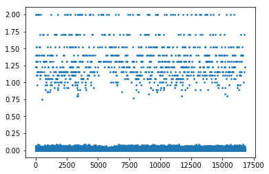

```python
import matplotlib.pyplot as plt
plt.scatter(co,piss, s=3 )
plt.show()
```